### How can I overlay genetics data?

Genoppi allows for visualization of experimental proteomics data with

- SNPs from genetic studies,
- user uploaded genes (e.g. set of interesting genes from [GTEx](http://www.gtexportal.org/home/)) to highlight corresponding proteins and
- protein encoded by genes that are intolerant to loss-of-function mutations as determined by [ExAC](http://exac.broadinstitute.org/) data

### SNP to gene mapping

The application will perform on-the-fly mapping of inputted SNPs to 1KG genotypes and translate to a list of genes. For each CEU imputed SNP, genomic locus is defined as region containing r2>0.6 to the associated SNP within a 200-kb window; this region is then extended by 50kb upstream and downstream. 50kb extension is set as default and user is able to choose the extension between 0 to 100kb. The threshold for LD measure is arbitrary – stringent is r2 >0.8, and relatively lenient is r2>0.5. The 2014 schizophrenia GWAS article (Ripke et al., 2014), cited over 1400 times, defines “associated locus as the physical region containing all SNPs correlated at r2>0.6” with each SNPs of interests, and we have implemented the same definition. SNPs are mapped to candidate genes if the genomic coordinates of human protein-coding genes in hg19 overlap SNP loci. Overlaps from single-gene locus are annotated as ‘SGL gene’ and if multiple protein-coding genes are present in SNP locus, all genes are mapped as candidate genes for the associated SNP and annotated as ‘MGL gene’ as shown in the figure below.

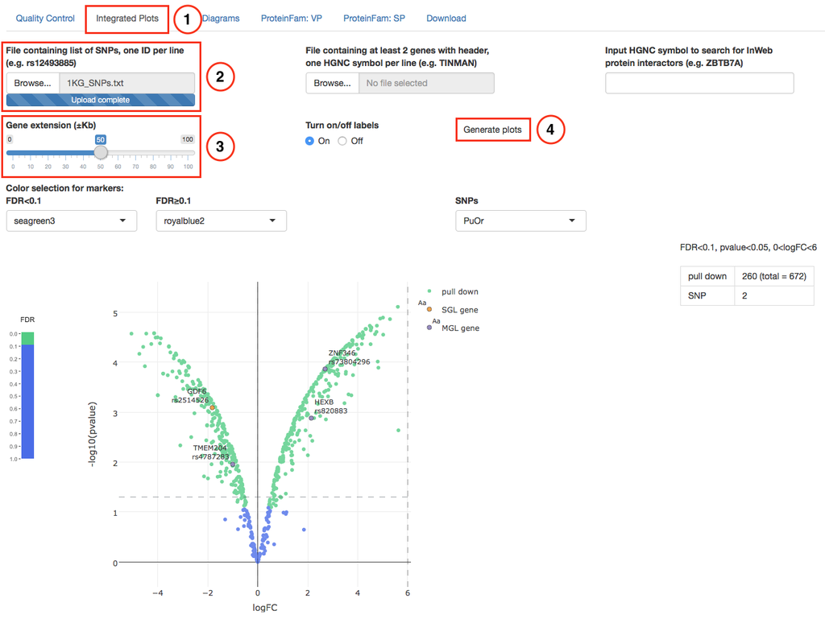

User may change the color theme for SNP markers by using the drop down menu titled “SNPs.”

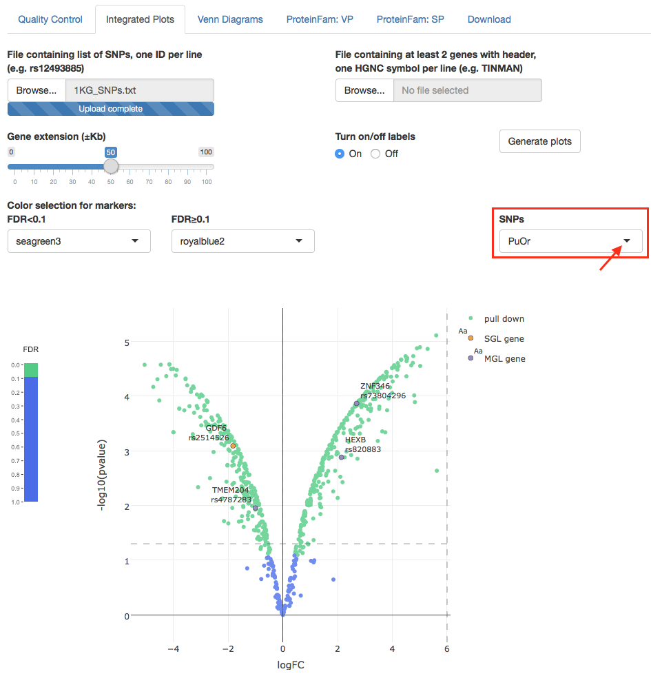

The mapping of SNP to gene using 20 random SNPs were performed using DAPPLE, a standard tool in the genetics community, and Genoppi to verify that SNP is correctly mapped to gene(s). As shown in the figure below, 100% of genes mapped from SNPs using DAPPLE are identified in Genoppi output. Genoppi mapping method does not discriminate against loci encoding for multiple genes and thus all genes encoded in respective loci are shown in the mapped result.

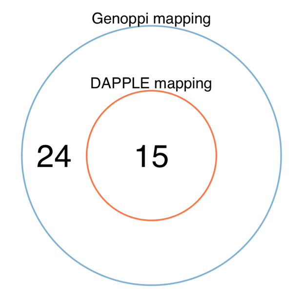

### Genes of interest

This feature allows users to highlight specific proteins corresponding to user’s uploaded genes of interest (e.g. a set of genes from the Genotype Tissue Expression [GTEx] project or from permutation based P-value calculations). User must upload a plain text file containing list(s) of corresponding protein’s genes in HGNC symbol for genes of interest mapping. First row of each column must contain the name describing the group of genes as shown below. There are no limits as to how many columns user may input.

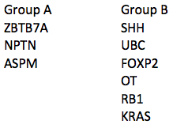

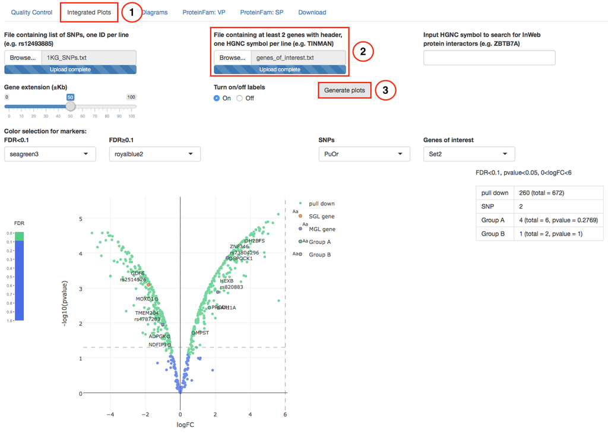

Upon upload, overlaps with proteomics results are visualized and statistically tested using hypergeometric distribution (Feller, 1968). A detailed counter and hypergeometric p-value is shown to the right of volcano plot. User may change the color theme by using the drop down menu titled ‘Genes of interest.’

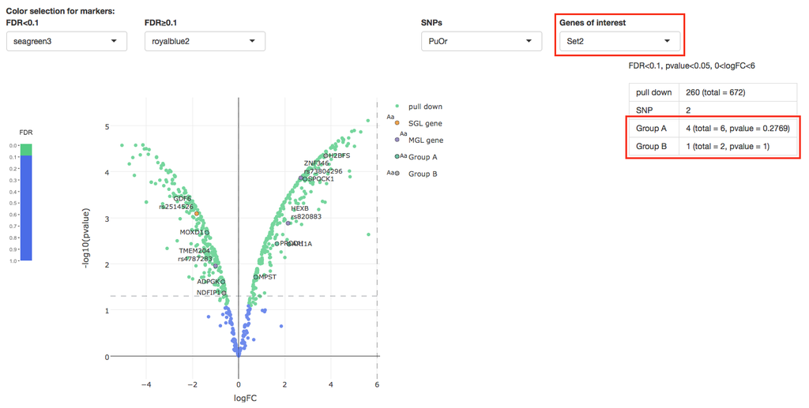

User may upload input files for both SNP to gene mapping and highlighting genes of interest as well as provide a HGNC symbol for searching interaction partners in InWeb. Any combination of fields may be filled and resulting plot will highlight all relevant proteins from user inputted data.

If, in the case, the plot becomes too “busy,” user can choose to turn the labels off or turn off the markers by clicking on the legend you wish to hide.

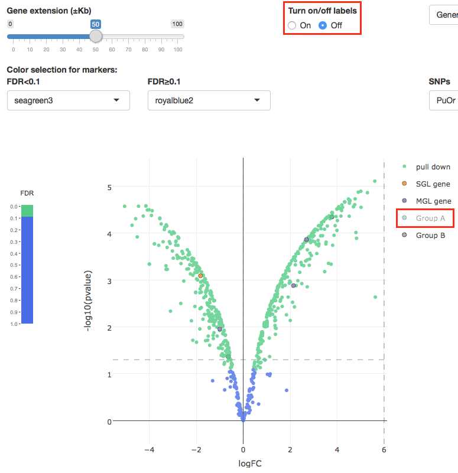

### Intolerance to LoF mutations determined by ExAC data

If at any point user would like to identify proteins encoded by genes likely to be extremely intolerant to loss-of-function variation using the ExAC data, user can choose the color scheme “ExAC” on the side panel. Please see ‘Quality Control’ documentation for further detail on overlaying ExAC data.

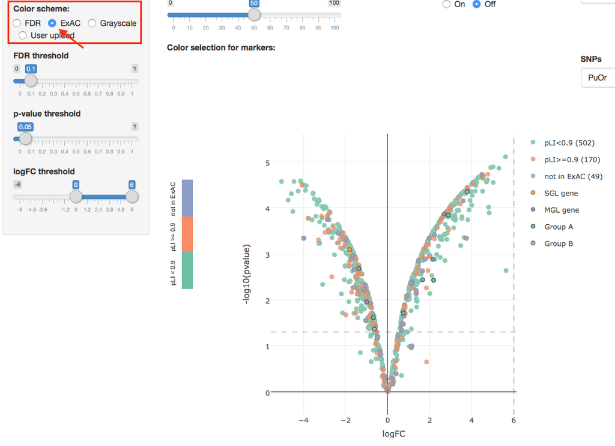

### References

Ripke, S., Neale, B.M., Corvin, A., Walters, J.T., Farh, K.H., Holmans, P.A., Lee, P., Bulik-Sullivan, B., Collier, D.A., Huang, H. and Pers, T.H., 2014. Biological insights from 108 schizophrenia-associated genetic loci. Nature, 511(7510), p.421.